# Assignment 2

Student ID: 10179889

# Overview

For this assignment, we have been provided with three different datasets. Using the knowledge we have gained from the workshops combined with further reading and wider resources, I will:

- Wrangle and tidy the data
- Summarise the data
- Visualise the data
- Build and interpret appropriate analyses

## Packages

First, let’s load in our packages using the `library()` function:

```r
library(tidyverse)
library(showtext)
library(afex)
library(emmeans)
library(visdat)
library(ggthemes)
```

The `{tidyverse}` package contains a collection of open source R packages that gives us access to a variety of useful functions and commands for data wrangling and visualisation. The `{showtext}` package enables us to load in and use over 1291 fonts from [Google Fonts](https://fonts.google.com/) for our data visualisations, whilst `{ggthemes}` contains extra themes for our plots. The `{afex}`and`{emmeans}` packages will allow us to build ANOVA models and perform post-hoc analyses, respectively. We’ll be using the `{afex]` package instead of the `aov()` function in base R as it allows us to build ANOVA models that will work for our experimental designs, as well as using type III sums of squares by default. Finally, `{visdat}` will help us to spot any missing data in our datasets.

# Question 1

Let’s read in our data and look over the information for question 1:

> We have 96 participants in a between participants design where we are interested in the effect of visual quality of a word on response time to pronounce the word. Our experimental factor (Visual Quality) has 2 levels (Normal vs. Degraded). The time it took for participants to pronounce the word, which was taken as a measure of reaction time in milliseconds, served as the dependent variable. Let’s read in our data:

```r
raw_data_1 <- read_csv("assignment_2_dataset_1.csv")
head(raw_data_1)
```

```
## # A tibble: 6 x 3
##   participant condition   response_time
##         <dbl> <chr>               <dbl>
## 1           1 condition_a          984.
## 2           2 condition_a         1005.
## 3           3 condition_a          979.
## 4           4 condition_a         1040.
## 5           5 condition_a         1008.
## 6           6 condition_a          979.
```

## Data Wrangling

Our Visual Quality variable is currently just named “condition” - let’s change it using the `rename()` function. Within the `mutate()` function, we can also modify it so it’s coded as a factor. Finally, our conditions are not labelled meaningfully and could lead to confusion further down the line. We can recode them using the `recode` command:

```r
q1_data_tidied <- raw_data_1 %>%
  rename(visual_quality = condition) %>%
  mutate(visual_quality = recode(visual_quality,
                            "condition_a" = "Normal",
                            "condition_b" = "Degraded")) %>%
  mutate(visual_quality = factor(visual_quality))
head(q1_data_tidied)
```

```
## # A tibble: 6 x 3
##   participant visual_quality response_time
##         <dbl> <fct>                  <dbl>
## 1           1 Normal                  984.
## 2           2 Normal                 1005.
## 3           3 Normal                  979.
## 4           4 Normal                 1040.
## 5           5 Normal                 1008.
## 6           6 Normal                  979.
```

## Data Summarising

We’ll first utilise the `group_by()` function to gather our visual-quality variable, then `summarise()` to create a new table consisting of Response Time mean and standard deviation. The data can be arranged from the fastest mean Response Time to the slowest using the `arrange()` function:

```r
q1_data_tidied %>%
  group_by(visual_quality) %>%
  summarise(mean = mean(response_time), sd = sd(response_time)) %>%
  arrange(mean)
```

```
## # A tibble: 2 x 3
##   visual_quality  mean    sd
##   <fct>          <dbl> <dbl>
## 1 Normal         1002.  21.0
## 2 Degraded       1020.  23.5
```

At a glance, it looks as though participants who were presented a word with normal visual quality were faster at pronouncing the word than those who were presented with a word with degraded quality. Since the output returned no NA results, we know that there is no missing data and therefore no reason to use the `vis_dat()` function. At this stage, we can create some data visualisations to better present our results.

## Data Visualisations

In this visualisation, we’re jittering the data points, meaning that every time we execute the code, the points will jitter to a different position. This implies that our code is not reproducible, because we don’t know the seed that R will use to generate the sequence. By setting the seed using the `set.seed()` function, we can ensure that the output will be the same every time it is run. I set the seed to 42 for its reference to Hitch Hikers Guide to the Galaxy…

```r
set.seed(42)
```

To be able to manipulate the font family, we first need to download a font from [Google Fonts](https://fonts.google.com). I decided to pick the ‘Lato’ Font, as its larger character height lends itself to easier readability at small sizes. Let’s read this font into R using the `font_add_()` command and tell `{showtext}` to automatically render the text:

```r
font_add("lato", regular = "lato-regular.ttf")
showtext_auto()
```

Next, we can build a visualisation by plotting the raw data points using the `geom_point` function, and the shape of the distribution for each condition using the `geom_violin()` function. By default, R will order the conditions alphabetically, so I used the `fct_relevel()` function to reorder the labels on the x-axis so that our ‘normal’ condition (the baseline) is on the left hand side. We have also added some summary data in the form of the Mean and Confidence Intervals around the mean using the `stat_summary()` function. Finally, we can dictate the y-axis breaks within the `scale_y_continuous()` function, and change the text font and size within the `theme()` argument:

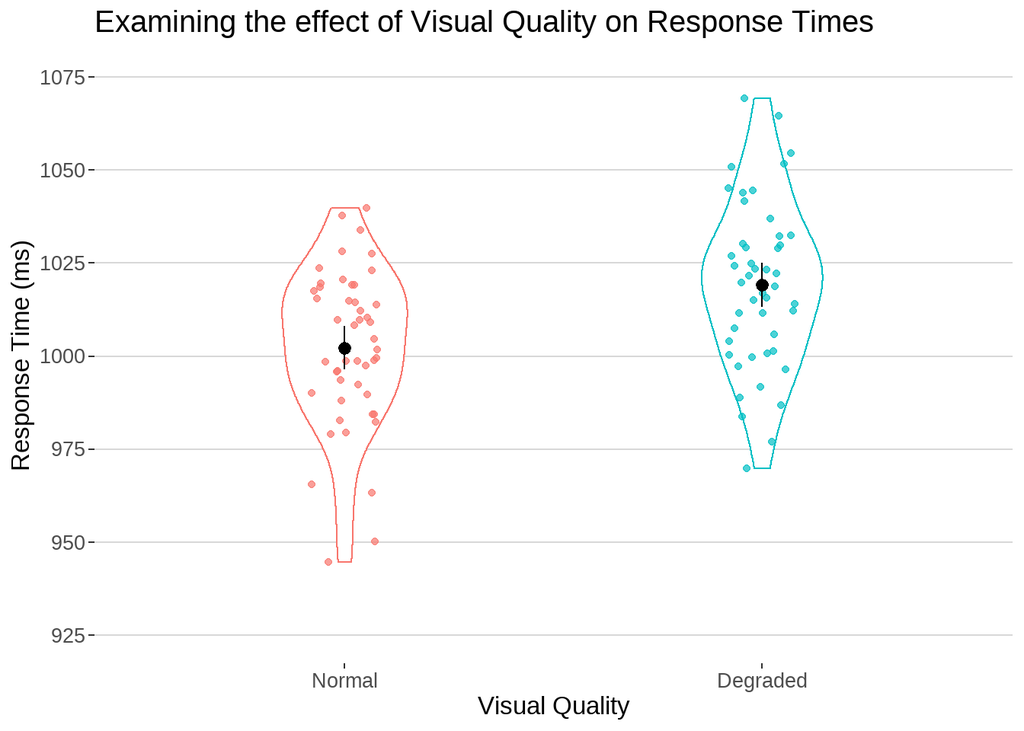

```r
q1_data_tidied %>%
  mutate(visual_quality = fct_relevel(visual_quality, "Normal", "Degraded")) %>%
  ggplot(aes(x = visual_quality, y = response_time, colour = visual_quality)) +
  geom_violin(width = 0.3) +
  geom_point(alpha = 0.7, position = position_jitter(width = 0.08, seed = 42)) +
  theme_hc() +
  stat_summary(fun.data = "mean_cl_boot", colour = "black") +
  guides(colour = 'none') +
  scale_y_continuous(breaks = seq(925, 1075, by = 25),
                     limits = c(925, 1075)) +
  labs(title = "Examining the effect of Visual Quality on Response Times",
       x = "Visual Quality",
       y = "Response Time (ms)") +
  theme(text = element_text(family = "Lato", size = 25))
```

## Building our ANOVA Model

Let’s now build our model using the `aov_4()` function in the `{afex}` package. Within this package, the syntax for ANOVA models is: `aov_4(DV ~ IV + (1 | participant), data = q1_data_tidied)`. The `~` symbol translates to ‘predicted by’, and the term `(1 | participant)` takes into account our random effect. We need to specify what data we are using in our model using `data = q1_data_tidied`. Finally, we map the output of the ANOVA result onto a variable I’ve called `between_anova`. This means that the ANOVA results will be stored in this variable and will allow us to access them later.

```r
between_anova <- aov_4(response_time ~ visual_quality + (1 | participant), data = q1_data_tidied)
```

## Interpreting the Model Output

We can view the output of our new ANOVA model using the `anova()` function:

```r
anova(between_anova)
```

```
## Anova Table (Type 3 tests)
##
## Response: response_time
##                num Df den Df    MSE      F     ges    Pr(>F)
## visual_quality      1     94 497.58 15.781 0.14375 0.0001393 ***
## ---
## Signif. codes:  0 '***' 0.001 '**' 0.01 '*' 0.05 '.' 0.1 ' ' 1
```

We can see that there is an effect in our model - the *p*-value is pretty small, but we don’t yet know what direction this is in. Although we could refer to the condition means, I’m going to run a pairwise comparison using the `emmeans()` function. There is no need to change the adjustment, as we’re not running multiple comparisons.

```r
emmeans(between_anova, pairwise ~ visual_quality)
```

```
## $emmeans
##  visual_quality emmean   SE df lower.CL upper.CL
##  Degraded         1020 3.22 94     1014     1027
##  Normal           1002 3.22 94      996     1009
##
## Confidence level used: 0.95
##
## $contrasts
##  contrast          estimate   SE df t.ratio p.value
##  Degraded - Normal     18.1 4.55 94   3.973  0.0001
```

An independent one-way ANOVA revealed a significant difference between IV level means, *F*(1,94) = 15.78, *p* < .001, generalised η2 = .14. Tukey comparisons revealed that the normal visual quality group pronounced the words significantly faster than the degraded visual quality group (*p* < .001)

In other words, participants were faster at pronouncing a word when the word was visually normal, compared to when the word was visually degraded.

# Question 2

First, we should read in our data and look over some of the characteristics of question 2:

> We have 96 participants in a between participants design where we are interested in the effect of visual quality of a word on response time to pronounce the word. We are also interested in whether caffeine consumption will contribute to any of the variance. Our experimental factor (Visual Quality) has 2 levels. These are Normal vs. Degraded, and Response Time is our DV measured on a continuous scale. Caffeine Consumption is our covariate and was measured by cups of coffee consumed. We’ll next read in our data:

```r
raw_data_2 <- read_csv("assignment_2_dataset_2.csv")
head(raw_data_2)
```

```
## # A tibble: 6 x 4
##   participant condition   response_time caffeine
##         <dbl> <chr>               <dbl>    <dbl>
## 1           1 condition_a          984.        1
## 2           2 condition_a         1005.        1
## 3           3 condition_a          979.        3
## 4           4 condition_a         1040.        2
## 5           5 condition_a         1008.        2
## 6           6 condition_a          979.        3
```

## Data Wrangling

Similar to before, we need to rename our ‘condition’ factor to ‘visual_quality’, code it as a factor, and name the conditions meaningfully:

```r
q2_data_tidied <- raw_data_2 %>%
  rename(visual_quality = condition) %>%
  mutate(visual_quality = recode(visual_quality,
                                 "condition_a" = "Normal",
                                 "condition_b" = "Degraded")) %>%
  mutate(visual_quality = factor(visual_quality))
head(q2_data_tidied)
```

```
## # A tibble: 6 x 4
##   participant visual_quality response_time caffeine
##         <dbl> <fct>                  <dbl>    <dbl>
## 1           1 Normal                  984.        1
## 2           2 Normal                 1005.        1
## 3           3 Normal                  979.        3
## 4           4 Normal                 1040.        2
## 5           5 Normal                 1008.        2
## 6           6 Normal                  979.        3
```

## Data Visualising

Let’s now have a look at the relationship between our experimental factor (Visual Quality), covariate (Caffeine Consumption), and our dependent variable (Response Time).

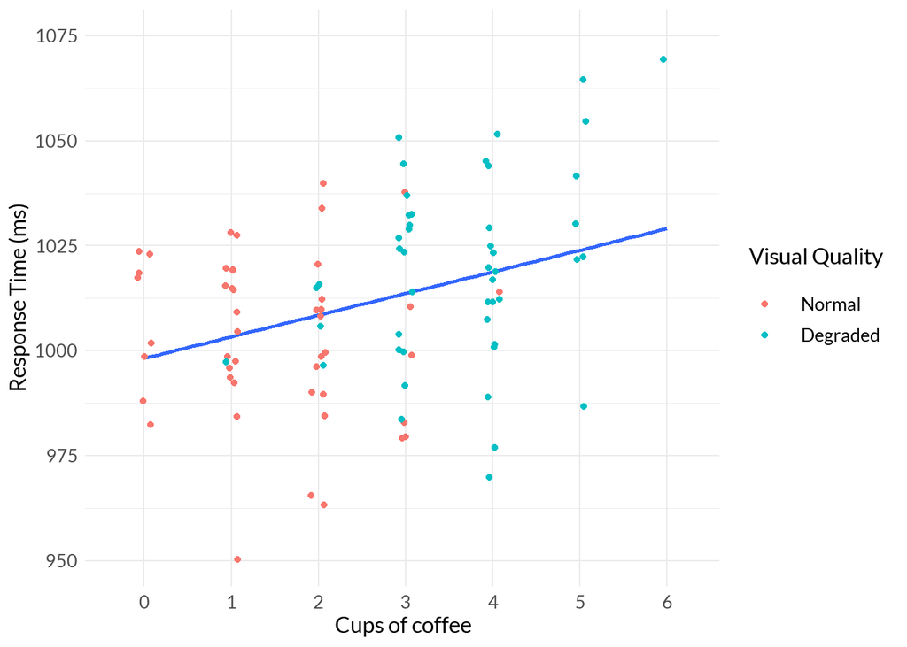

```r
q2_data_tidied %>%
  mutate(visual_quality = fct_relevel(visual_quality, "Normal", "Degraded")) %>%
  ggplot(aes(x = caffeine, y = response_time, colour = visual_quality)) +
  geom_smooth(aes(x = caffeine, y = response_time), inherit.aes = FALSE,
              method = "lm", se = FALSE) +
  geom_point(size = 1.5, position = position_jitter(width = 0.08, seed = 42)) +
  theme_minimal() +
  labs(x = "Cups of coffee",
       y = "Response Time (ms)",
       colour = "Visual Quality") +
  scale_y_continuous(breaks = seq(950, 1075, by = 25),
                     limits = c(950, 1075)) +
    scale_x_discrete(breaks = seq(0, 6, by = 1),
                   limits = seq(0, 6)) +
  theme(text = element_text(family = "lato", size = 25))
```

In this visualisation, I have added in a regression line that depicts the correlation between our covariant, Caffeine, and our DV, Response Time, using the `geom_smooth()` function. In our `geom_smooth` command, I was able to remove our experimental factor, Visual Quality, from the regression line by specifying what data to include using the `aes()` function, and for this data to supersede our graph aesthetics using `inherit.aes = FALSE`.

We can see from our regression line that there isn’t a particularly strong relationship between Caffeine and Response Time. Interestingly, our Caffeine consumption groups appear to be clustering in our data by Visual Quality, suggesting that our covariate may have an effect on the relationship between Visual Quality and Caffeine. Let’s build an ANCOVA model to test this assumption.

## Building our ANCOVA Model

We saw in our first dataset that Visual Quality had a significant effect on Response Time, with participants who were presented with visually normal words pronouncing them quicker than participants who were presented with visually degraded words. However, let’s control for the effect of our covariate by building an ANCOVA model which includes Caffeine, ensuring that we add our covariate before our experimental condition manipulation. We set the factorize parameter to FALSE so that Caffeine is treated as a continuous predictor, rather than an experimental factor in our model.

```r
model_ancova <- aov_4(response_time ~ caffeine + visual_quality + (1 | participant), data = q2_data_tidied, factorize = FALSE)
anova(model_ancova)
```

```
## Anova Table (Type 3 tests)
##
## Response: response_time
##                num Df den Df    MSE      F      ges  Pr(>F)
## caffeine            1     93 496.95 1.1188 0.011888 0.29291
## visual_quality      1     93 496.95 3.5730 0.036998 0.06184 .
## ---
## Signif. codes:  0 '***' 0.001 '**' 0.01 '*' 0.05 '.' 0.1 ' ' 1
```

Now, when we control the effect of our covariate (Caffeine), we can see that the effect of Visual Quality, that previously was *F* = 15.78, is now *F* = 3.57, and our *p* value is no longer significant (*p* = .062). Moreover, as we assumed in our visualisation, our covariate is also non-significant, *F* = 1.12, *p* = .293. Following on from this, we can use the `emmeans()` function to produce the adjusted means for each of our two experimental groups, taking into account the influence of our covariate. I will also perform an unadjusted marginal means test without the covariate as I did in question 1 so that we can compare them.

**Unadjusted means**

```r
emmeans(between_anova, pairwise ~ visual_quality)
```

```
## $emmeans
##  visual_quality emmean   SE df lower.CL upper.CL
##  Degraded         1020 3.22 94     1014     1027
##  Normal           1002 3.22 94      996     1009
##
## Confidence level used: 0.95
##
## $contrasts
##  contrast          estimate   SE df t.ratio p.value
##  Degraded - Normal     18.1 4.55 94   3.973  0.0001
```

**Adjusted means**

```r
emmeans(model_ancova, pairwise ~ visual_quality)
```

```
## $emmeans
##  visual_quality emmean   SE df lower.CL upper.CL
##  Degraded         1018 4.08 93     1010     1026
##  Normal           1005 4.08 93      997     1013
##
## Confidence level used: 0.95
##
## $contrasts
##  contrast          estimate   SE df t.ratio p.value
##  Degraded - Normal     12.8 6.77 93   1.890  0.0618
```

We can see that our adjusted means differ from our unadjusted means for our experimental groups, although this difference is fairly small. Furthermore, our two adjusted means are still fairly far apart (normal = 1005, degraded = 1018), and can probably account for why our *p* value (*p* = .062) was very close to the significance threshold of .05.